# Are Players Getting Paid Accurately

### Gradient Boost Hitting

We are going to try a range of thresholds to see where might be a good stopping point to counter complexity with having the right amount of invormation.

```python
# Define thresholds to experiment with
thresholds = [0.005, 0.01, 0.02]
performance_metrics = []

# Split the data into training and test sets (e.g., 80% train, 20% test)
X_batting = merged_batting.drop(columns=['top_earner', 'value'])
y_batting = merged_batting['top_earner']
X_train_full, X_test, y_train_full, y_test = train_test_split(X_batting, y_batting, test_size=0.2, random_state=42)

# Loop through each threshold
for threshold in thresholds:
    # Filter features based on the importance threshold from Random Forest
    important_features = importance_df[importance_df['Importance'] >= threshold]['Feature'].tolist()
    X_train_selected = X_train_full[important_features]

    # Cross-validation to measure performance on the training data with the selected features
    gb_model = GradientBoostingClassifier(random_state=42)
    cv_scores = cross_val_score(gb_model, X_train_selected, y_train_full, cv=5, scoring='roc_auc')
    avg_cv_score = np.mean(cv_scores)

    # Fit Gradient Boosting on the full training set with selected features
    gb_model.fit(X_train_selected, y_train_full)

    # Store performance metrics for each threshold
    performance_metrics.append({
        'Threshold': threshold,
        'Features Used': len(important_features),
        'Average CV ROC AUC': avg_cv_score
    })

# Convert to DataFrame for easy viewing
performance_df = pd.DataFrame(performance_metrics)
print("Performance on Training Data (using Cross-Validation):")
print(performance_df)

# Choose the threshold that provided the best cross-validation performance
best_threshold = performance_df.loc[performance_df['Average CV ROC AUC'].idxmax(), 'Threshold']
best_features = importance_df[importance_df['Importance'] >= best_threshold]['Feature'].tolist()
print(f"\nBest threshold: {best_threshold} with features: {best_features}")

# Final Model Training and Evaluation on Test Set with the Best Threshold
X_train_best = X_train_full[best_features]
X_test_best = X_test[best_features]

# Train Gradient Boosting on the entire training data with the best feature subset
gb_final_model = GradientBoostingClassifier(random_state=42)
gb_final_model.fit(X_train_best, y_train_full)

# Predict on the test set
y_pred = gb_final_model.predict(X_test_best)
y_pred_proba = gb_final_model.predict_proba(X_test_best)[:, 1]

# Evaluate the final model on the test set
accuracy = accuracy_score(y_test, y_pred)
roc_auc = roc_auc_score(y_test, y_pred_proba)
f1 = f1_score(y_test, y_pred)

print("\nFinal Gradient Boosting Model Performance on Test Set:")
print(f"Accuracy: {accuracy:.2f}")
print(f"ROC AUC Score: {roc_auc:.2f}")
print(f"F1 Score: {f1:.2f}")
print("\nClassification Report:")
print(classification_report(y_test, y_pred))
```

```
Performance on Training Data (using Cross-Validation):
   Threshold  Features Used  Average CV ROC AUC
0      0.005             32            0.691874
1      0.010             32            0.691874
2      0.020             32            0.691874

Best threshold: 0.005 with features: ['xwoba', 'b_rbi', 'hard_hit_percent', 'pa', 'bb_percent', 'on_base_plus_slg', 'exit_velocity_avg', 'solidcontact_percent', 'avg_hyper_speed', 'woba', 'xwobacon', 'k_percent', 'on_base_percent', 'avg_best_speed', 'oz_swing_percent', 'walk', 'swing_percent', 'hit'…

Final Gradient Boosting Model Performance on Test Set:
Accuracy: 0.78
ROC AUC Score: 0.70
F1 Score: 0.41

Classification Report:
              precision    recall  f1-score   support

           0       0.80      0.93      0.86        88
           1       0.60      0.31      0.41        29

    accuracy                           0.78       117
   macro avg       0.70      0.62      0.64       117
weighted avg       0.75      0.78      0.75       117
```

#### Final Model Performance on Test Set

Using the selected threshold (0.005) and the corresponding 32 features, the Gradient Boosting model was evaluated on the test set:

1. **Overall Performance**:
   - **Accuracy**: 78%
   - **ROC AUC Score**: 0.70
   - **F1 Score**: 0.41
2. **Classification Report**:
   - The model shows a higher **precision** (0.80) and **recall** (0.93) for the non-top earners (`0` class).
   - For the top earners (`1` class), precision is 0.60, but recall is lower at 0.31, indicating the model struggles with identifying high earners.
   - The macro averages reflect moderate balance across classes, with an F1-score weighted average of 0.75.

### Summary

The Gradient Boosting model, with a threshold of 0.005 for feature selection, performs reasonably well on the test set, particularly in identifying non-top earners. However, recall for top earners remains low, suggesting further tuning may be needed to improve balance between classes. The chosen feature set (32 features) provides a balance between maximizing predictive power and avoiding unnecessary complexity.

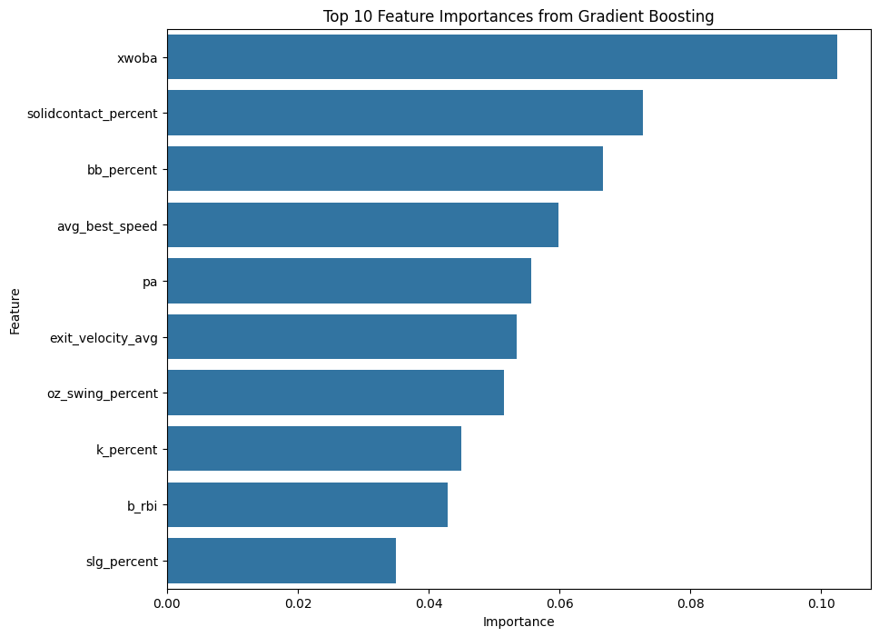

[figure not shown]

```python
# Get feature importances from the trained Gradient Boosting model
feature_importances = gb_final_model.feature_importances_
features = X_train_best.columns

# Create a DataFrame for feature importances
importance_df = pd.DataFrame({'Feature': features, 'Importance': feature_importances})
importance_df = importance_df.sort_values(by='Importance', ascending=False)

# 1. Bar Plot of Top 10 Feature Importances
plt.figure(figsize=(10, 8))
sns.barplot(x='Importance', y='Feature', data=importance_df.head(10))
plt.title("Top 10 Feature Importances from Gradient Boosting")
plt.show()

# 2. Cumulative Feature Importance Plot
importance_df['Cumulative Importance'] = importance_df['Importance'].cumsum()
plt.figure(figsize=(10, 6))
plt.plot(importance_df['Cumulative Importance'], marker='o')
plt.xlabel('Number of Features')
plt.ylabel('Cumulative Importance')
plt.title("Cumulative Feature Importance")
plt.axhline(y=0.9, color='r', linestyle='--', label='90% Cumulative Importance')
plt.legend()
plt.show()
```

### Comparison of Feature Importances in Random Forest and Gradient Boosting Models

In comparing the feature importances from the **Random Forest** and **Gradient Boosting** models, we observe some differences in which features are prioritized, reflecting the unique ways each algorithm identifies and uses patterns in the data:

1. **Top Features in Each Model**:
   - Both models agree on the importance of **xwOBA** (expected weighted on-base average) as the most influential feature for predicting high earners, suggesting it is a reliable metric across models.
   - However, the **Random Forest** model places significant weight on **b_rbi** (runs batted in) and **hard hit percent**, while **Gradient Boosting** prioritizes **solid contact percent** and **bb percent** (walk rate).
2. **Differences in Ranking**:
   - In the Gradient Boosting model, **avg_best_speed** (possibly measuring the peak speed of the ball off the bat) is among the top features, whereas it doesn’t feature as prominently in Random Forest’s ranking.
   - The Random Forest model, on the other hand, highlights **on_base_plus_slg** (OPS) and **wOBA** in its top 10, which are lower in importance in the Gradient Boosting model.
3. **Algorithm Characteristics Impacting Feature Importance**:
   - **Random Forest** is an ensemble of fully grown decision trees, making it sensitive to features that provide clear, early splits. It often ranks features that contribute to larger, immediate information gains higher, even if they’re not subtle predictors.
   - **Gradient Boosting** builds trees sequentially, focusing on correcting errors from previous iterations. This allows it to capture complex, incremental patterns, often making it more sensitive to features that have predictive value in combination with others, which may differ from Random Forest’s feature selection.
4. **Deciding Which Features to Utilize**:
   - **Intersection of Top Features**: We can focus on features that appear important in both models, like **xwOBA**, **exit velocity average**, and **bb percent**. These shared features are likely to be genuinely impactful across different learning techniques.
   - **Algorithm-Specific Insights**: For a Gradient Boosting model, we may retain features like **solid contact percent** and **avg_best_speed** since these appear uniquely important in boosting’s iterative framework.
   - **Comprehensive Feature Set**: We could take the union of the top features across both models, especially since ensemble models are robust to some redundancy and can handle a larger feature set without severe overfitting risks.

**Summary** In practice, combining insights from both models allows us to create a balanced feature set that incorporates core, high-impact metrics (like xwOBA) while considering algorithm-specific preferences. This approach enhances the robustness of feature selection, making it more adaptable to different models.